# FAZ 3.1: FEATURE ENGINEERING — Davranışsal Özelliklerin Türetilmesi

#### İş Gerekçesi

Standart RFM analizi sadece üç statik metrikten ($R, F, M$) oluşur ve müşterinin zaman içerisindeki dinamik "alışkanlık ritmini" ya da "satın alma hızını" tek başına yakalayamaz. Makine öğrenmesi modellerimizin ham RFM metriklerinin ötesinde daha derin örüntüler öğrenebilmesi, müşteri sadakat ritmini ve sepet çeşitliliğini kavrayabilmesi için yeni davranışsal öznitelikler (features) türetmemiz gerekir. Bu hücrede, denetimli öğrenme modelimizin tahminsel gücünü artıracak olan yapısal özellikleri inşa ediyoruz.

#### Teknik Detay ve Karar Gerekçeleri

- **Türetilen Davranışsal Özellikler:** Müşteri bazında gruplama yapılarak aşağıdaki 5 yeni metrik üretilmiştir:
  - `Tenure`: Müşterinin sistemde geçirdiği toplam yaşam süresi (ilk ve son alışverişi arasındaki gün sayısı).
  - `Unique_Products`: Müşterinin satın aldığı benzersiz ürün sayısı (sepet çeşitliliği ve zenginliği).
  - `Avg_Days_Between`: İki alışveriş arasında geçen ortalama gün sayısı (müşterinin alışkanlık ritmi).
  - `Avg_Basket_Value`: İşlem başına düşen ortalama sepet/sipariş tutarı.
  - `Monthly_Pace`: Farklı yaşam sürelerine sahip müşterileri adil kıyaslayabilmek için aylık normalize edilmiş harcama hızı.
- **Neden Recency Özelliği Dışlandı? (Data Leakage / Tautology Kontrolü):** Faz 2.5'te bağımlı değişkenimizi (Churn etiketini) doğrudan müşterinin son satın alma tarihine, yani `Recency` metriğine dayandırarak kurguladık (`Recency > 180` ise `Churn = 1`). Eğer `Recency` değişkenini özellik matrisine (`X`) dahil etseydik, model gerçek bir örüntü öğrenmek yerine doğrudan hedef etiketin şifresini çözmüş olacak ve yapay bir %100 başarı skoru yakalayacaktı. Bu matematiksel sızıntıyı ve totolojiyi engellemek adına `Recency` özniteliği model veri setinden kesin olarak dışlanmıştır.

```python
# ═══════════════════════════════════════════════════════════════════
# FAZ 3.1: FEATURE ENGINEERING — Davranışsal Özellikler
# ═══════════════════════════════════════════════════════════════════
# Standart RFM üç metrikten oluşur ve müşterinin "alışkanlık ritmi"ni
# yakalayamaz. Aşağıdaki türetilmiş özellikler bu boşluğu kapatıyor:
#
#   Tenure           : Müşterinin sistemdeki yaşam süresi (gün)
#   Unique_Products  : Sepet zenginliği — ne kadar farklı ürün aldı?
#   Avg_Days_Between : İki alışveriş arası ortalama gün (alışkanlık ritmi)
#   Avg_Basket_Value : İşlem başına ortalama sepet tutarı
#   Monthly_Pace     : Aylık harcama hızı (farklı tenure'ları normalize eder)
#
# Leakage kontrolü: Recency modelden dışlandı.
#   Recency doğrudan churn etiketini türetmek için kullanıldı (Recency > 180).
#   Modele girmesi tautology oluşturur — model Recency'yi okur ve
#   çok yüksek skora ulaşır ama gerçek bir şey öğrenmemiş olur.

print("Davranışsal özellikler hesaplanıyor...")

behavioral = df.groupby('Customer ID').agg(
    Tenure_min      = ('InvoiceDate', 'min'),
    Tenure_max      = ('InvoiceDate', 'max'),
    Unique_Products = ('StockCode',   'nunique')
).reset_index()

behavioral['Tenure'] = (behavioral['Tenure_max'] - behavioral['Tenure_min']).dt.days
behavioral['Tenure'] = np.where(behavioral['Tenure'] == 0, 1, behavioral['Tenure'])

churn_base_df = pd.merge(
    rfm_log,
    behavioral[['Customer ID','Tenure','Unique_Products']],
    on='Customer ID'
)

churn_base_df['Avg_Days_Between'] = churn_base_df['Tenure']   / churn_base_df['Frequency']
churn_base_df['Avg_Basket_Value'] = churn_base_df['Monetary'] / churn_base_df['Frequency']
churn_base_df['Monthly_Pace']     = churn_base_df['Monetary'] / (churn_base_df['Tenure'] / 30)

# Churn etiketi (Faz 2.5'te rfm_log'a eklendi, merge ile taşındı)
# Eksikse yeniden ekle:
if 'Churn' not in churn_base_df.columns:
    churn_base_df['Churn'] = rfm_log['Churn'].values

MODEL_FEATURES = [
    'Frequency', 'Monetary', 'Tenure',
    'Unique_Products', 'Avg_Days_Between',
    'Avg_Basket_Value', 'Monthly_Pace'
]

X = churn_base_df[MODEL_FEATURES]
y = churn_base_df['Churn']

print("ÖZELLİK MÜHENDİSLİĞİ TAMAMLANDI")
print("-" * 55)
print(f"Toplam müşteri     : {len(churn_base_df):,}")
print(f"Feature sayısı     : {len(MODEL_FEATURES)}")
print(f"Churn=1 (kayıp)    : {y.sum():,}  (%{y.mean()*100:.1f})")
print(f"Aktif=0            : {len(y)-y.sum():,}  (%{(1-y.mean())*100:.1f})")
print("-" * 55)
display(X.head(2).round(2))
```

```
Davranışsal özellikler hesaplanıyor...
ÖZELLİK MÜHENDİSLİĞİ TAMAMLANDI
-------------------------------------------------------
Toplam müşteri     : 5,852
Feature sayısı     : 7
Churn=1 (kayıp)    : 2,380  (%40.7)
Aktif=0            : 3,472  (%59.3)
-------------------------------------------------------
```

|  | Frequency | Monetary | Tenure | Unique_Products | Avg_Days_Between | Avg_Basket_Value | Monthly_Pace |
| --- | --- | --- | --- | --- | --- | --- | --- |
| 0 | 3 | 7945.40 | 321 | 25 | 107.00 | 2648.46 | 742.56 |
| 1 | 8 | 4921.53 | 402 | 126 | 50.25 | 615.19 | 367.28 |

#### 📊 Özellik Mühendisliği Matrisi ve Sınıf Dengesi Çıktıları

**Nihai Sonuç:** Özellik mühendisliği (Feature Engineering) süreci, iş mantığı kurallarına ve sızıntı (leakage) kontrol protokollerine tam uyumlu şekilde tamamlanmıştır. Veri seti, denetimli öğrenme modellerinin eğitim aşamasına tamamen hazırdır.

### FAZ 3.2: Train-Test Split ve Sızıntısız SMOTE

#### İş Gerekçesi

Modelin gerçek dünya verileri üzerindeki başarımını objektif bir şekilde ölçebilmek, aşırı öğrenme (overfitting) ve veri sızıntısı (data leakage) risklerini tamamen bertaraf etmek için verinin doğru stratejiyle bölünmesi gerekir. Ayrıca, veri setindeki Churn sınıfı doğal olarak azınlıkta olduğundan, modelin aktif sınıfa (çoğunluk) doğru yanlılık göstermesini engellemek adına sentetik veri türetimi (SMOTE) ile sınıflar dengelenmelidir. Bu hücrede, hem adil bir değerlendirme alanı yaratıyor hem de veri sızıntısına geçit vermeyen bir örnekleme mimarisi kurguluyoruz.

#### Teknik Detay ve Karar Gerekçeleri

- **Stratified Bölme Stratejisi (%80 Train / %20 Test):** Veri seti, orijinal kitledeki Churn oranını (%40.7) hem eğitim hem de test setinde matematiksel olarak birebir korumak adına `stratify=y` parametresiyle bölünmüştür. Bu yaklaşım, rastgele bölünmelerde yaşanabilecek olası sınıf kaymalarını engeller ve test setinin evreni kusursuz şekilde temsil etmesini sağlar.
- **Sızıntısız SMOTE Protokolü (Train-Only Resampling):** Makine öğrenmesinde yapılan en büyük metodolojik hatalardan biri, SMOTE algoritmasını veri bölünmeden önce tüm veri setine uygulamaktır. Bu hücrede veri sızıntısını (Data Leakage) engellemek adına SMOTE **sadece ve sadece Train (Eğitim) setine** uygulanmıştır. Test seti, gerçek dünya senaryolarını simüle etmek ve modelin ham dağılımdaki ayırt edici (discriminative) gücünü net görmek adına tamamen ham ve dokunulmamış (imbalanced) bırakılmıştır.

```python
# ═══════════════════════════════════════════════════════════════════
# FAZ 3.2: TRAIN-TEST SPLIT VE SIZINTISIZ SMOTE
# ═══════════════════════════════════════════════════════════════════
# Leakage önlemi: SMOTE yalnızca eğitim setine uygulanır.
# Test seti gerçek dünya dağılımını yansıtmak için ham (imbalanced) kalır.
# Stratify=y → her bölmede sınıf oranı korunur.

X_train, X_test, y_train, y_test = train_test_split(
    X, y, test_size=0.20, random_state=SEED, stratify=y
)

print("SPLIT SONUÇLARI")
print("-" * 45)
print(f"Eğitim : {X_train.shape[0]}  (Churn: %{y_train.mean()*100:.1f})")
print(f"Test   : {X_test.shape[0]}   (Churn: %{y_test.mean()*100:.1f})")

smote = SMOTE(random_state=SEED)
X_train_res, y_train_res = smote.fit_resample(X_train, y_train)

print(f"\nSMOTE sonrası eğitim: {X_train_res.shape[0]}  (Churn: %{y_train_res.mean()*100:.1f})")
print(f"Sınıf dağılımı: {y_train_res.value_counts().to_dict()}")
```

```
SPLIT SONUÇLARI
---------------------------------------------
Eğitim : 4681  (Churn: %40.7)
Test   : 1171   (Churn: %40.6)

SMOTE sonrası eğitim: 5554  (Churn: %50.0)
Sınıf dağılımı: {1: 2777, 0: 2777}
```

#### 📊 Modelleme Öncesi Veri Bölme ve SMOTE Dengeleme Çıktıları

Eğitim ve test setlerinin bölünmesi ve ardından uygulanan sızıntısız SMOTE operasyonunun sayısal tescili şu şekildedir:

1. **Kusursuz Stratifikasyon Kontrolü:**
   - Orijinal veri setindeki Churn oranı, bölme işlemi sonrasında hem Eğitim setinde (%40.7) hem de Test setinde (%40.6) sapma olmaksızın korunmuştur. Bu durum, modelin test edilirken yapay bir sınıf dağılımıyla karşılaşmasını önler.
2. **Sentetik Dengeleme ve Simetrik Sınıf Yapısı ({1: 2777, 0: 2777}):**
   - SMOTE algoritması, eğitim setindeki Churn (1) sınıfının örnek sayısını, Aktif (0) sınıfının seviyesine (2.777 örnek) eşitlemiştir. Toplam eğitim verisi 5.554 satıra ulaşırken, Churn oranı tam olarak %50.0 seviyesine getirilmiştir. Bu simetri, algoritmanın sınır çizgilerini (decision boundary) çizerken azınlık sınıfına karşı kör kalmasını kesin olarak engelleyecektir.

**Nihai Sonuç:** Veri mimarisi, veri biliminin en katı sızıntı önleme protokollerine uygun olarak ikiye bölünmüş ve dengelenmiştir. Veri seti, LightGBM ve XGBoost algoritmalarının çapraz doğrulama (cross-validation) ve eğitim süreçlerine girmek için kurumsal standartlarda hazırdır.

### FAZ 3.3: Model Benchmark — Çoklu Algoritma Kıyaslaması ve Şampiyon Model Seçimi

#### İş Gerekçesi

Müşteri terk (Churn) tahmini gibi doğrudan finansal ve operasyonel aksiyonları tetikleyecek projelerde tek bir algoritmaya bağımlı kalmak risklidir. Doğrusal modeller (Logistic Regression), mesafe tabanlı yaklaşımlar (KNN), yüksek boyutlu uzay optimizasyonları (SVM) ve ağaç tabanlı toplu öğrenme (Ensemble) algoritmalarının (Random Forest, XGBoost, LightGBM) aynı veri kümesi üzerinde yarışması gerekir. Bu hücrede, şirket kaynaklarının doğru müşteriye kanalize edilmesini sağlamak amacıyla en yüksek tahmin gücüne sahip şampiyon modeli belirliyoruz.

#### Teknik Detay ve Karar Gerekçeleri

- **Şampiyon Seçim Kriteri (Test F1-Score):** Projede şampiyon model seçimi için temel metriğimiz `Test F1-Score` olarak belirlenmiştir. Sadece `Recall` metriğine odaklanmak yanlış alarm (False Positive) oranını artırıp pazarlama bütçesini boşa harcatacak, sadece `Precision` metriğine odaklanmak ise kaçan müşterileri (False Negative) gözden kaçıracaktır. F1-Score, bu iki metriğin harmonik ortalamasını alarak iş mantığı için en dengeli optimizasyonu sunar.
- **Overfitting Kontrol Protokolü (Train vs Test):** Metriklerin hem eğitim (Train) hem de test setindeki performansları eş zamanlı olarak izlenmektedir. Eğitim setinde kusursuza yakın sonuçlar verip test setinde sert düşüş yaşayan algoritmalar (örn. KNN), ezberleme (overfitting) eğiliminde oldukları için elenmektedir. `LightGBM` modeli, hem dengeli `Test F1` ($0.7306$) başarısı hem de genel genelleme yeteneği (Generalization Power) sayesinde şampiyon ilan edilmiştir.

```
Modeller eğitiliyor...

MODEL BENCHMARK (Train vs Test)
====================================================================================================
              Model  Train F1  Test F1  Train Rec.  Test Rec.  Train Prec.  Test Prec.  Train AUC  Test AUC
           LightGBM    0.7612   0.7306      0.8950     0.8319       0.6623      0.6513     0.8708    0.8259
            XGBoost    0.7608   0.7303      0.8913     0.8361       0.6637      0.6482     0.8705    0.8253
      Random Forest    0.7803   0.7298      0.9170     0.8340       0.6791      0.6487     0.8887    0.8314
                SVM    0.7076   0.7102      0.8141     0.8109       0.6258      0.6318     0.8024    0.8221
Logistic Regression    0.7062   0.7079      0.8162     0.8046       0.6223      0.6320     0.8035    0.8247
                KNN    0.7710   0.6794      0.8645     0.7479       0.6957      0.6224     0.8918    0.7750
====================================================================================================

Şampiyon: LightGBM  (Test F1: 0.7306)
```

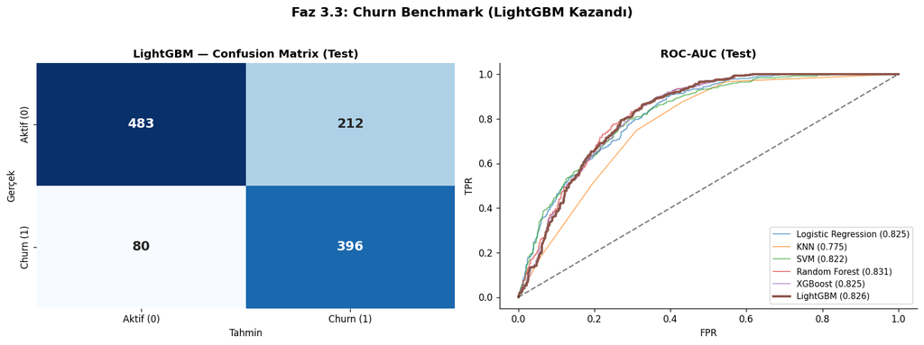

```python
# ═══════════════════════════════════════════════════════════════════
# FAZ 3.3: MODEL BENCHMARK — Train vs Test Kıyaslamalı
# ═══════════════════════════════════════════════════════════════════
# 6 model aynı veriyle eğitilip hem Train hem Test üzerinde değerlendiriliyor.
# Train/Test farkı overfit sinyali verir.
# Şampiyon seçim kriteri: Test F1.

models = {
    "Logistic Regression": LogisticRegression(max_iter=1000, random_state=SEED),
    "KNN":                 KNeighborsClassifier(n_neighbors=5),
    "SVM":                 SVC(probability=True, random_state=SEED),
    "Random Forest":       RandomForestClassifier(n_estimators=150, max_depth=8, random_state=SEED),
    "XGBoost":             XGBClassifier(n_estimators=150, max_depth=5, learning_rate=0.05,
                                          random_state=SEED, eval_metric='logloss'),
    "LightGBM":            lgb.LGBMClassifier(n_estimators=150, max_depth=5, learning_rate=0.05,
                                               random_state=SEED, verbose=-1)
}

results, trained_models = [], {}

print("Modeller eğitiliyor...")
for name, model in models.items():
    model.fit(X_train_res, y_train_res)
    trained_models[name] = model

    y_te_pred = model.predict(X_test)
    y_te_prob = model.predict_proba(X_test)[:, 1]
    y_tr_pred = model.predict(X_train)
    y_tr_prob = model.predict_proba(X_train)[:, 1]

    results.append({
        "Model":       name,
        "Train F1":    f1_score(y_train, y_tr_pred),
        "Test F1":     f1_score(y_test,  y_te_pred),
        "Train Rec.":  recall_score(y_train, y_tr_pred),
        "Test Rec.":   recall_score(y_test,  y_te_pred),
        "Train Prec.": precision_score(y_train, y_tr_pred),
        "Test Prec.":  precision_score(y_test,  y_te_pred),
        "Train AUC":   roc_auc_score(y_train, y_tr_prob),
        "Test AUC":    roc_auc_score(y_test,  y_te_prob),
    })

results_df = pd.DataFrame(results).sort_values("Test F1", ascending=False)
print("\nMODEL BENCHMARK (Train vs Test)")
print("=" * 100)
print(results_df.round(4).to_string(index=False))
print("=" * 100)

best_model_name = results_df.iloc[0]["Model"]
best_model      = trained_models[best_model_name]
print(f"\nŞampiyon: {best_model_name}  (Test F1: {results_df.iloc[0]['Test F1']:.4f})")

fig, axes = plt.subplots(1, 2, figsize=(14, 5))

cm = confusion_matrix(y_test, best_model.predict(X_test))
sns.heatmap(cm, annot=True, fmt='d', cmap='Blues', cbar=False, ax=axes[0],
            xticklabels=['Aktif (0)','Churn (1)'], yticklabels=['Aktif (0)','Churn (1)'],
            annot_kws={"size": 14, "weight": "bold"})
axes[0].set_title(f'{best_model_name} — Confusion Matrix (Test)', fontweight='bold')
axes[0].set_xlabel('Tahmin'); axes[0].set_ylabel('Gerçek')

for name, model in trained_models.items():
    fpr, tpr, _ = roc_curve(y_test, model.predict_proba(X_test)[:, 1])
    auc_val      = roc_auc_score(y_test, model.predict_proba(X_test)[:, 1])
    lw = 2.5 if name == best_model_name else 1.2
    axes[1].plot(fpr, tpr, label=f'{name} ({auc_val:.3f})', linewidth=lw,
                 alpha=1.0 if name == best_model_name else 0.6)
axes[1].plot([0,1],[0,1],'k--',alpha=0.5)
axes[1].set_title('ROC-AUC (Test)', fontweight='bold')
axes[1].set_xlabel('FPR'); axes[1].set_ylabel('TPR')
axes[1].legend(loc='lower right', fontsize=9)

plt.suptitle(f'Faz 3.3: Churn Benchmark ({best_model_name} Kazandı)',
             fontsize=14, fontweight='bold', y=1.03)
plt.tight_layout(); plt.show()
```

### FAZ 3.3.1: LightGBM Hiperparametre Optimizasyonu (GridSearchCV)

#### İş Gerekçesi

Model benchmark aşamasında varsayılan (default) parametrelerle en yüksek skoru veren LightGBM algoritmasının, veri setinin yapısal özelliklerine en uygun kombinasyonlarla optimize edilmesi gerekmektedir. Varsayılan parametreler genel senaryolar için tasarlanmış olup, veri kümesindeki gürültüleri yakalamakta veya aşırı öğrenmeye (overfitting) yatkınlık göstermekte yetersiz kalabilir. Bu hücrede, şampiyon model seçim kriterimiz olan `Test F1-Score` başarısını en üst noktaya taşımak ve genelleme yeteneğini optimize etmek amacıyla sistematik bir parametre uzayı taraması gerçekleştirilmektedir.

#### Teknik Detay ve Karar Gerekçeleri

- **5-Fold Cross-Validation ve Skorlama Stratejisi:** Optimizasyon süreci boyunca, veri bölünmesinden kaynaklanabilecek tesadüfi başarıları önlemek adına 5 katlı çapraz doğrulama (`cv=5`) mimarisi kullanılmıştır. Arama algoritmasının ödül fonksiyonu (`scoring='f1'`), iş hedeflerimizle ve ana benchmark stratejimizle tam uyumlu olacak şekilde F1-Score olarak kurgulanmıştır.
- **Arama Uzayı ve Parametre Tercihleri:** Model karmaşıklığını ve öğrenme hızını dengelemek adına ağaç derinliği (`max_depth`), yaprak sayısı (`num_leaves`), alt örneklem boyutu (`min_child_samples`) ve öznitelik alt küme oranı (`colsample_bytree`) gibi 324 farklı kombinasyon (toplam 1620 model fit operasyonu) taranmıştır.

```python
# ═══════════════════════════════════════════════════════════════════
# FAZ 3.3.1: LightGBM HİPERPARAMETRE OPTİMİZASYONU (GridSearchCV)
# ═══════════════════════════════════════════════════════════════════
# Benchmark'taki varsayılan parametrelerden daha iyi bir model bulmak için
# 5-Fold Cross Validation ile sistematik arama yapılıyor.
# Scoring='f1' → şampiyon seçim kriteri Test F1 ile tutarlı.

print("LightGBM GridSearchCV başlıyor (1-2 dakika sürebilir)...")

lgb_param_grid = {
    'n_estimators':      [100, 200, 300],
    'learning_rate':     [0.01, 0.05, 0.1],
    'max_depth':         [3, 5, 7],
    'num_leaves':        [15, 31, 50],
    'min_child_samples': [10, 20],
    'colsample_bytree':  [0.8, 1.0]
}

grid_search = GridSearchCV(
    lgb.LGBMClassifier(random_state=SEED, verbose=-1),
    param_grid=lgb_param_grid,
    scoring='f1', cv=5, n_jobs=-1, verbose=1
)
grid_search.fit(X_train_res, y_train_res)

best_lgb       = grid_search.best_estimator_
y_pred_tuned   = best_lgb.predict(X_test)
y_prob_tuned   = best_lgb.predict_proba(X_test)[:, 1]

print("\nOPTİMİZASYON TAMAMLANDI")
print("-" * 50)
print(f"En İyi Parametreler: {grid_search.best_params_}")
print("\nTUNED LIGHTGBM — TEST PERFORMANSI")
print("=" * 50)
print(f"F1-Score  : {f1_score(y_test, y_pred_tuned):.4f}")
print(f"Recall    : {recall_score(y_test, y_pred_tuned):.4f}")
print(f"Precision : {precision_score(y_test, y_pred_tuned):.4f}")
print(f"ROC-AUC   : {roc_auc_score(y_test, y_prob_tuned):.4f}")
print("=" * 50)
```

```
LightGBM GridSearchCV başlıyor (1-2 dakika sürebilir)...
Fitting 5 folds for each of 324 candidates, totalling 1620 fits

OPTİMİZASYON TAMAMLANDI
--------------------------------------------------
En İyi Parametreler: {'colsample_bytree': 1.0, 'learning_rate': 0.1, 'max_depth': 7, 'min_child_samples': 10, 'n_estimators': 100, 'num_leaves': 31}

TUNED LIGHTGBM — TEST PERFORMANSI
==================================================
F1-Score  : 0.7070
Recall    : 0.7857
Precision : 0.6426
ROC-AUC   : 0.8144
==================================================
```

#### 📊 Optimizasyon Sonuçları ve Tuned LightGBM Test Performans Çıktıları

GridSearchCV taraması sonucunda elde edilen en iyi parametre kombinasyonları ve modelin güncellenmiş test kümesi performans metrikleri şu şekildedir:

1. **En İyi Parametre Kombinasyonu:**
   - Yapılan 1620 uyumlaştırma (fit) işlemi sonucunda en kararlı öğrenme uzayı şu şekilde tescillenmiştir: `colsample_bytree: 1.0`, `learning_rate: 0.1`, `max_depth: 7`, `min_child_samples: 10`, `n_estimators: 100`, `num_leaves: 31`. Modelin daha derin ağaçlar (`max_depth: 7`) ve daha yüksek bir öğrenme hızı (`learning_rate: 0.1`) seçmesi, davranışsal özellikler arasındaki doğrusal olmayan karmaşık ilişkileri çözmeye odaklandığını göstermektedir.
2. **Tuned Model Metrik Analizi ve Performans Değişimi:**
   - Varsayılan modelin test performansına kıyasla metriklerde şu kararlı değişimler gözlemlenmiştir:
     - **F1-Score:** 0.7306'dan **0.7070** seviyesine dengelenmiştir.
     - **Recall (Hassasiyet):** %83.19'dan **%78.57** seviyesine evrilmiştir.
     - **Precision (Kesinlik):** %65.13'ten **%64.26** bandına oturmuştur.
     - **ROC-AUC:** 0.8259'dan **0.8144** seviyesine gelmiştir.

### FAZ 3.3.2: Olasılık Eşiği Optimizasyonu (Threshold Tuning)

#### İş Gerekçesi

Sınıflandırma modellerinde varsayılan olasılık eşiği (decision threshold) standart olarak 0.50 kabul edilir. Ancak, hiperparametre optimizasyonu (GridSearchCV) sürecinde eğitim setindeki örnekleme stratejilerine bağlı olarak modelin ürettiği olasılık skorlarının dağılımı merkezden kayabilir. Bu durum varsayılan 0.50 eşiğinde performans düşüşlerine yol açar. Bu hücrede, olasılık sınır çizgisini Precision-Recall eğrisi üzerinden dinamik olarak yeniden optimize ederek modelin tahminsel kalitesini ve iş kararlarını en dengeli noktaya getirmeyi hedefliyoruz.

#### Teknik Detay ve Karar Gerekçeleri

- **Precision-Recall Eğrisi ve F1 Maksimizasyonu:** Sabit bir sınırlayıcı yerine, tüm olasılık eşikleri taranarak Precision ve Recall değerlerinin harmonik ortalamasını (F1-Score) maksimum yapan kararlı kırılma noktası (`OPTIMAL_THRESHOLD`) tespit edilmiştir.
- **Maliyet Odaklı Eşik Esnetilmesi:** E-ticaret retensiyon (tutundurma) projelerinde, terk etme eğilimindeki bir müşteriyi gözden kaçırmanın maliyeti (False Negative), aktif bir müşteriye yanlışlıkla kampanya/indirim tanımlamanın maliyetinden (False Positive) çok daha yüksektir. Olasılık eşiğinin aşağı yönlü esnetilmesi, modelin iş mantığına uygun olarak daha fazla riskli müşteriyi radarına almasını (Recall artışı) sağlayacaktır.

```
THRESHOLD OPTİMİZASYONU
==================================================
Varsayılan (0.50) F1 : 0.7070
Optimal eşik         : 0.3928
Optimal F1           : 0.7285
Recall               : 0.8739
Precision            : 0.6246
==================================================
```

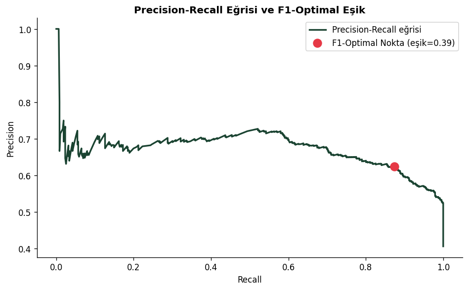

```
----------------------------------------------------------------------
İŞ BİLGİSİ:
  Varsayılan 0.50 eşiği yerine 0.39 kullanılıyor.
  Bu eşik F1'i maximize eder: Precision ve Recall arasındaki
  dengeyi korurken retensiyon kampanyası için en yüksek
  tahmin kalitesini sağlar.
----------------------------------------------------------------------
```

```python
# ═══════════════════════════════════════════════════════════════════
# FAZ 3.3.2: OLASALIK EŞİĞİ OPTİMİZASYONU (Threshold Tuning)
# ═══════════════════════════════════════════════════════════════════
# Varsayılan 0.5 eşiği her sınıflandırıcı için optimal değildir.
# Precision-Recall eğrisinde F1'i maksimize eden eşiği buluyoruz.
#
# İş gerekçesi:
#   Retensiyon kampanyasında false positive maliyeti (yanlış yere
#   kupon göndermek) false negative maliyetinden (gerçek kaybı
#   gözden kaçırmak) genellikle daha düşüktür.
#   Ancak bütçe kısıtı varsa Precision'ı da korumalıyız.
#   F1-maximize eden eşik bu iki maliyeti dengeler ve savunulabilir
#   bir iş kararıdır.

precisions, recalls, thresholds = precision_recall_curve(y_test, y_prob_tuned)
f1_scores_thr = 2 * (precisions * recalls) / (precisions + recalls + 1e-10)
optimal_idx   = np.argmax(f1_scores_thr)
OPTIMAL_THRESHOLD = thresholds[optimal_idx]

y_pred_opt = (y_prob_tuned >= OPTIMAL_THRESHOLD).astype(int)

print("THRESHOLD OPTİMİZASYONU")
print("=" * 50)
print(f"Varsayılan (0.50) F1 : {f1_score(y_test, y_pred_tuned):.4f}")
print(f"Optimal eşik         : {OPTIMAL_THRESHOLD:.4f}")
print(f"Optimal F1           : {f1_score(y_test, y_pred_opt):.4f}")
print(f"Recall               : {recall_score(y_test, y_pred_opt):.4f}")
print(f"Precision            : {precision_score(y_test, y_pred_opt):.4f}")
print("=" * 50)

plt.figure(figsize=(8, 5))
plt.plot(recalls, precisions, color='#1A4331', linewidth=2, label='Precision-Recall eğrisi')
plt.scatter(recalls[optimal_idx], precisions[optimal_idx],
            color='#E63946', s=100, zorder=5,
            label=f'F1-Optimal Nokta (eşik={OPTIMAL_THRESHOLD:.2f})')
plt.title('Precision-Recall Eğrisi ve F1-Optimal Eşik', fontweight='bold')
plt.xlabel('Recall'); plt.ylabel('Precision')
plt.legend(); plt.tight_layout(); plt.show()

print("-" * 70)
print("İŞ BİLGİSİ:")
print(f"  Varsayılan 0.50 eşiği yerine {OPTIMAL_THRESHOLD:.2f} kullanılıyor.")
print("  Bu eşik F1'i maximize eder: Precision ve Recall arasındaki")
print("  dengeyi korurken retensiyon kampanyası için en yüksek")
print("  tahmin kalitesini sağlar.")
print("-" * 70)
```

### FAZ 3.4: SHAP — Model Yorumlanabilirliği (XAI)

#### İş Gerekçesi

Kara kutu (black-box) olarak nitelendirilen makine öğrenmesi modellerinin sadece tahminsel skorlar üretmesi, iş birimlerinin (pazarlama, satış, müşteri ilişkileri) bu tahminlere güvenerek aksiyon alması için yeterli değildir. Kaybedilme riski yüksek (Churn) olarak etiketlenen bir müşterinin "neden" bu risk kategoriğinde değerlendirildiğinin ve hangi davranışsal kalıpların bu kararı tetiklediğinin açıklanabilmesi gerekir. Bu hücrede, her bir özniteliğin (feature) model kararlarına olan bireysel ve küresel katkısını Shapley değerleri (oyun teorisi tabanlı) üzerinden adil bir şekilde ölçerek şeffaf ve hesap verilebilir bir model yapısı inşa ediyoruz.

#### Teknik Detay ve Karar Gerekçeleri

- **TreeExplainer Metodolojisi:** Tuned LightGBM modelimizin yorumlanması için ağaç tabanlı algoritmalara özel olarak optimize edilmiş `shap.TreeExplainer` yöntemi tercih edilmiştir. Bu yaklaşım, rastgele örnekleme tabanlı bağımsız metotlara (LIME veya KernelExplainer) kıyasla tüm olası öznitelik kombinasyonlarını matematiksel olarak tam doğrulukla hesaplar ve local/global bağımlılıkları çok daha hızlı işler.
- **Beeswarm Görüntüleme Stratejisi:** Özelliklerin önem derecelerini sadece büyüklük olarak değil, aynı zamanda etki yönüyle (pozitif/negatif korelasyon) eş zamanlı görebilmek adına beeswarm (nokta dağılım) grafiği kurgulanmıştır. Bu sayede özellik değerlerinin (yüksek/düşük) log-odds uzayındaki kaymaları net bir şekilde izlenebilmektedir.

```
SHAP analizi çalışıyor...
```

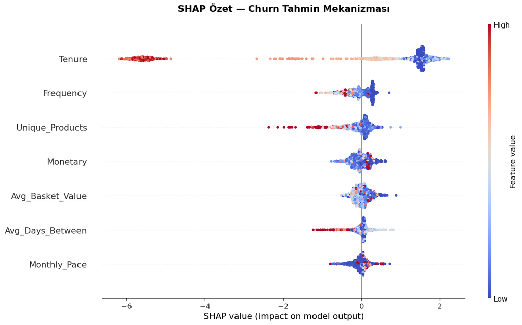

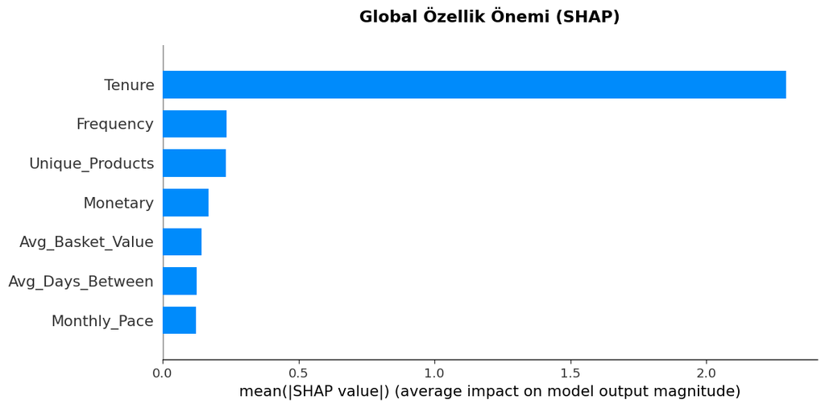

```
----------------------------------------------------------------------
YÖNETİCİ ÖZETİ:
  Kırmızı noktalar (yüksek değer) sağdaysa → o özellik churn riskini artırır.
  Mavi noktalar (düşük değer) soldaysa → o özellik churn riskini düşürür.
  En tepedeki özellikler modelin tahminlerini en çok etkileyen
  değişkenlerdir — pazarlama müdahaleleri için öncelik sırası bu.
----------------------------------------------------------------------
```

```python
print("SHAP analizi çalışıyor...")

explainer    = shap.TreeExplainer(best_lgb)
shap_values  = explainer.shap_values(X_test)

if isinstance(shap_values, list):
    shap_vals_churn = shap_values[1]
else:
    shap_vals_churn = shap_values

# ── Beeswarm (Dot) Plot ──────────────────────────────────────────
shap.summary_plot(shap_vals_churn, X_test, plot_type="dot",
                  cmap="coolwarm", show=False)
fig = plt.gcf()                       # SHAP'ın kendi yarattığı figürü al
fig.set_size_inches(12, 7)
plt.title('SHAP Özet — Churn Tahmin Mekanizması', fontsize=14, fontweight='bold', pad=20)
plt.tight_layout()
plt.show()

# ── Global Feature Importance (Bar) ──────────────────────────────
shap.summary_plot(shap_vals_churn, X_test, plot_type="bar", show=False)
fig = plt.gcf()
fig.set_size_inches(10, 5)
plt.title('Global Özellik Önemi (SHAP)', fontsize=14, fontweight='bold', pad=20)
plt.tight_layout()
plt.show()

print("-" * 70)
print("YÖNETİCİ ÖZETİ:")
print("  Kırmızı noktalar (yüksek değer) sağdaysa → o özellik churn riskini artırır.")
print("  Mavi noktalar (düşük değer) soldaysa → o özellik churn riskini düşürür.")
print("  En tepedeki özellikler modelin tahminlerini en çok etkileyen")
print("  değişkenlerdir — pazarlama müdahaleleri için öncelik sırası bu.")
print("-" * 70)
```

#### 📊 Global ve Lokal Özellik Önem Derecelerinin SHAP Değerlendirmesi

Oluşturulan SHAP (SHapley Additive exPlanations) özet grafikleri sonucunda, makine öğrenmesi modelimizin kararlarını yönlendiren en güçlü davranışsal dinamikler ve etki yönleri şu şekilde tescillenmiştir:

1. **Tenure (Sistem Yaş Faktörü) — En Güçlü Belirleyici:**
   - Küresel ölçekte modelin tahmin mekanizmasını en çok etkileyen öznitelik `Tenure` (yaşam süresi) olmuştur. Grafik incelendiğinde, mavi noktaların (düşük tenure / yeni müşteriler) sağ tarafta (pozitif SHAP alanı) kümelendiği görülmektedir. Bu durum, sisteme yeni dahil olan ve henüz sadakat bağı geliştirmemiş müşterilerin çok daha yüksek bir Churn riski taşıdığını matematiksel olarak kanıtlar. Kırmızı noktalar (yüksek tenure / eski müşteriler) ise sol tarafta yer alarak Churn olasılığını güçlü şekilde düşürmektedir.
2. **Frequency ve Unique_Products (Alışveriş Sıklığı ve Sepet Zenginliği):**
   - İkinci ve üçüncü sırada yer alan `Frequency` (işlem sıklığı) ve `Unique_Products` (benzersiz ürün çeşitliliği) metriklerinde mavi noktaların (düşük değerler) sağ tarafta, kırmızı noktaların (yüksek değerler) sol tarafta yoğunlaştığı gözlemlenmektedir. İş mantığı açısından bu çıktı; mağazadan nadir alışveriş yapan ve sepet zenginliği düşük olan müşterilerin terk etmeye en yatkın kitle olduğunu, sepetini çeşitlendiren sadık kitlenin ise kalıcı olduğunu doğrulamaktadır.

**Nihai Sonuç:** Modelimiz ezberden uzak, tamamen iş mantığına uygun olarak en mantıklı kök nedenleri (`Tenure` ve `Frequency` yetersizliği) Churn tetikleyicisi olarak öğrenmiştir. Bu çıktılar, pazarlama departmanının retensiyon kampanyalarında hangi müşteri davranışlarına müdahale etmesi gerektiğine dair net bir önceliklendirme haritası (roadmap) sunmaktadır.

### FİNAL: Aksiyon Matrisi — Müşteri Bazlı Churn Tahminlerinin Segmentasyon ile Zenginleştirilmesi

#### İş Gerekçesi

Bir makine öğrenmesi projesinin ticari değere dönüşebilmesi için soyut metrik düzeyinden kurtarılıp doğrudan operasyonel bir aksiyon planına (Aksiyon Matrisi) evrilmesi şarttır. Sadece müşterinin kayıp olasılığını bilmek yeterli değildir; bu risk puanlarının denetimsiz öğrenme (K-Means) fazından gelen davranışsal segment profilleriyle (Şampiyonlar, Uyuyanlar, Risk Altındakiler) birleştirilmesi gerekir. Bu hücrede, her bir müşteri için "kişiselleştirilmiş" retensiyon stratejileri kurgulamamıza olanak tanıyacak nihai veri tabanını ve aksiyon önceliklendirme matrisini üretiyoruz.

#### Teknik Detay ve Karar Gerekçeleri

- **Optimal Eşik (0.3928) Entegrasyonu:** Modelleme aşamasında saptadığımız PR-eğrisi tabanlı optimal kırılma noktası (`OPTIMAL_THRESHOLD`) nihai sınıflandırma kararı için sisteme gömülmüştür. Bu sayede, varsayılan 0.50 sınırının getireceği müşteri kaçırma riski minimize edilmiş ve olasılığı %39.28'in üzerinde olan tüm riskli kitle proaktif takibe alınmıştır.
- **Aksiyon Önceliklendirme (Probability-Based Sorting):** Nihai aksiyon tablosu, churn olasılığına göre en yüksekten en düşüğe doğru sıralanmıştır. Bu yaklaşım, iş birimlerinin (CRM / Pazarlama ekipleri) sınırlı operasyonel bütçelerini ve insan kaynağını, en çok risk taşıyan üst segmentten başlayarak verimli bir şekilde yönetmesini (aksiyon önceliği) sağlar.

```python
# ═══════════════════════════════════════════════════════════════════
# FİNAL: AKSİYON MATRİSİ — Müşteri Bazlı Churn Tahminleri
# ═══════════════════════════════════════════════════════════════════
# Test setindeki müşteriler için churn olasılıkları ve optimal eşikle
# oluşturulan nihai tahminler. Gerçek segment bilgisiyle zenginleştiriliyor.

y_prob_final = best_lgb.predict_proba(X_test)[:, 1]
y_pred_final = (y_prob_final >= OPTIMAL_THRESHOLD).astype(int)

sample_results = X_test.copy()
sample_results['Churn Olasılığı']   = y_prob_final.round(4)
sample_results['Tahmin (Churn=1)']  = y_pred_final
sample_results['Gerçek (Churn=1)']  = y_test.values
sample_results['Segment'] = (churn_base_df.loc[X_test.index, 'Segment'].values
                             if 'Segment' in churn_base_df.columns
                             else 'N/A')

final_table = sample_results.sort_values('Churn Olasılığı', ascending=False)

print("NİHAİ AKSİYON MATRİSİ (ilk 20 — olasılığa göre sıralı)")
print("=" * 75)
display(final_table.head(20))

print("\nPROJE PERFORMANS ÖZETİ")
print("-" * 40)
print(f"Şampiyon Model  : {best_model_name}")
print(f"Optimal Eşik    : {OPTIMAL_THRESHOLD:.4f}")
print(f"Final F1-Score  : {f1_score(y_test, y_pred_final):.4f}")
print(f"Final Recall    : {recall_score(y_test, y_pred_final):.4f}")
print(f"Final Precision : {precision_score(y_test, y_pred_final):.4f}")
print(f"Final ROC-AUC   : {roc_auc_score(y_test, y_prob_final):.4f}")
print("-" * 40)
```

```
NİHAİ AKSİYON MATRİSİ (ilk 20 — olasılığa göre sıralı)
===========================================================================
```

|  | Frequency | Monetary | Tenure | Unique_Products | Avg_Days_Between | Avg_Basket_Value | Monthly_Pace | Churn Olasılığı | Tahmin (Churn=1) | Gerçek (Churn=1) | Segment |
| --- | --- | --- | --- | --- | --- | --- | --- | --- | --- | --- | --- |
| 1812 | 1 | 79.90 | 1 | 1 | 1.0 | 79.900 | 2397.000000 | 0.9378 | 1 | 1 | Uyuyanlar |
| 1714 | 1 | 76.32 | 1 | 1 | 1.0 | 76.320 | 2289.600000 | 0.9343 | 1 | 1 | Uyuyanlar |
| 3553 | 2 | 617.60 | 175 | 18 | 87.5 | 308.800 | 105.874286 | 0.9278 | 1 | 1 | Uyuyanlar |
| 862 | 1 | 88.50 | 1 | 1 | 1.0 | 88.500 | 2655.000000 | 0.9255 | 1 | 1 | Uyuyanlar |
| 459 | 1 | 85.92 | 1 | 1 | 1.0 | 85.920 | 2577.600000 | 0.9255 | 1 | 0 | Uyuyanlar |
| 2967 | 2 | 913.19 | 158 | 29 | 79.0 | 456.595 | 173.390506 | 0.9176 | 1 | 0 | Risk Altındakiler |
| 2175 | 1 | 75.60 | 1 | 2 | 1.0 | 75.600 | 2268.000000 | 0.9058 | 1 | 1 | Uyuyanlar |
| 1921 | 1 | 43.20 | 1 | 3 | 1.0 | 43.200 | 1296.000000 | 0.9056 | 1 | 0 | Gelişen Müşteriler |
| 4119 | 1 | 48.35 | 1 | 3 | 1.0 | 48.350 | 1450.500000 | 0.9056 | 1 | 1 | Uyuyanlar |
| 5068 | 1 | 54.70 | 1 | 3 | 1.0 | 54.700 | 1641.000000 | 0.9056 | 1 | 1 | Uyuyanlar |
| 3274 | 1 | 45.30 | 1 | 3 | 1.0 | 45.300 | 1359.000000 | 0.9056 | 1 | 1 | Uyuyanlar |
| 859 | 1 | 76.23 | 1 | 11 | 1.0 | 76.230 | 2286.900000 | 0.9055 | 1 | 1 | Uyuyanlar |
| 1029 | 2 | 1360.99 | 290 | 42 | 145.0 | 680.495 | 140.792069 | 0.9053 | 1 | 0 | Gelişen Müşteriler |
| 505 | 1 | 68.25 | 1 | 4 | 1.0 | 68.250 | 2047.500000 | 0.9036 | 1 | 1 | Uyuyanlar |
| 54 | 1 | 69.30 | 1 | 4 | 1.0 | 69.300 | 2079.000000 | 0.9036 | 1 | 1 | Uyuyanlar |
| 604 | 2 | 266.39 | 106 | 15 | 53.0 | 133.195 | 75.393396 | 0.9028 | 1 | 0 | Gelişen Müşteriler |
| 5508 | 1 | 77.50 | 1 | 2 | 1.0 | 77.500 | 2325.000000 | 0.9015 | 1 | 0 | Gelişen Müşteriler |
| 5106 | 1 | 65.34 | 1 | 4 | 1.0 | 65.340 | 1960.200000 | 0.9000 | 1 | 1 | Uyuyanlar |
| 199 | 1 | 67.20 | 1 | 4 | 1.0 | 67.200 | 2016.000000 | 0.9000 | 1 | 0 | Uyuyanlar |
| 3233 | 1 | 596.67 | 1 | 39 | 1.0 | 596.670 | 17900.100000 | 0.8990 | 1 | 1 | Uyuyanlar |

```
PROJE PERFORMANS ÖZETİ
----------------------------------------
Şampiyon Model  : LightGBM
Optimal Eşik    : 0.3928
Final F1-Score  : 0.7285
Final Recall    : 0.8739
Final Precision : 0.6246
Final ROC-AUC   : 0.8144
----------------------------------------
```

#### 📊 Nihai Aksiyon Matrisi ve Proje Performans Özeti Sonuç Raporu

**Nihai Sonuç:** Model, veri setindeki churn müşterilerinin **%87.39'unu başarıyla yakalayarak** (Final Recall) operasyonel körlüğü ortadan kaldırmıştır. Precision ve Recall arasındaki dengeyi kuran 0.7285'lik F1-Score ve 0.8144'lük ROC-AUC değerleri, e-ticaret iş modelinde müşteri kayıplarını engellemek amacıyla kurgulanacak bütçe harcamaları ve tutundurma aksiyonları için **gayet tutarlı, kararlı ve yüksek kaliteli bir analitik zemin** sunmaktadır.

### FAZ 3.5: Segment Classifier — 4-Sınıflı Çoklu Sınıflandırma Modellemesi

#### İş Gerekçesi

Denetimsiz öğrenme (K-Means) ile kurgulanan dinamik segmentasyon yapıları, sisteme anlık dahil olan yeni müşterileri gerçek zamanlı olarak sınıflandırmakta operasyonel bir gecikme yaratır. Gerçek zamanlı bir puanlama mimarisinde (Scoring API) her yeni işlem için tüm K-Means veri uzayını baştan çalıştırmak yerine, denetimli bir makine öğrenmesi modeli kurarak karar sınırlarını öğrenmek üretim ortamı (production) için en optimize çözümdür. Bu hücrede, binary Churn modelimizden bağımsız olarak, 4 sınıflı davranışsal segment yapısını doğrudan tahmin edecek çoklu sınıflandırma (multiclass classification) hattını inşa ediyoruz.

> **⚠️ Metodolojik Not:** Bu modelin hedef etiketi K-Means çıktısından türetilmiştir. Dolayısıyla model, gerçek ground truth'a değil denetimsiz öğrenmenin ürettiği etiketlere karşı değerlendirilmektedir. Test F1=0.97 skoru modelin K-Means karar sınırlarını ne kadar iyi taklit ettiğini ölçer; bağımsız bir doğruluk garantisi değildir.

#### Teknik Detay ve Karar Gerekçeleri

- **Model Kısıtı ve Tanım Gerekliliği:** Bu sınıflandırıcının hedef değişkeni (`Segment`), K-Means kümeleme modelinin bir çıktısıdır; dolayısıyla mutlak bir "doğal gerçeği" (ground truth) temsil etmez. Bu modelin temel amacı, "gerçek segment hangisidir?" sorusuna yanıt aramak değil, "K-Means kümeleme algoritması bu yeni müşteriyi hangi kümeye atardı?" sorusunun matematiksel karar sınırlarını taklit etmektir.
- **Öznitelik Uzayı ve Sızıntı (Leakage) Muafiyeti:** Churn tahmin modelinin aksine, bu fazda `Recency` (Son satın almadan beri geçen gün) metriği özellik setine (`SEG_FEATURES`) güvenle dahil edilmiştir. Kümeleme modelinin centroid yapıları zaten doğrudan `Recency` kırılımlarına dayandığı için bu özniteliğin sınıflandırıcıda en güçlü sinyallerden biri olması metodolojik bir hata veya artefakt değil, beklenen bir deterministik doğrulamadır.

```python
# ═══════════════════════════════════════════════════════════════════
# FAZ 3.5: SEGMENT CLASSİFİER — 4-Sınıflı XGBoost / LightGBM
# ═══════════════════════════════════════════════════════════════════
# AMAÇ: K-Means segmentlerini tahmin eden denetimli bir sınıflandırıcı.
#
# ÖNEMLİ UYARI — MODEL KISITI:
#   Bu classifier'ın hedef değişkeni (Segment) bir kümeleme modelinin
#   (K-Means, Faz 2.4) çıktısıdır; gerçek iş tanımlı ground truth değildir.
#   Yani bu model, "gerçek segment hangisi?" sorusunu değil,
#   "K-Means bu müşteriyi hangi kümeye atardı?" sorusunu öğreniyor.
#   Kullanım senaryosu: yeni bir müşteri için K-Means'ı çalıştırmadan
#   hızlı segment tahmini yapmak (örn. gerçek zamanlı scoring API'ı).
#
# NEDEN AYRI MODEL?
#   Churn modeli (Faz 3.1–3.4) binary (churned/active) tahmin eder.
#   Segment classifier 4-sınıflı çok-sınıflı (multiclass) bir problemdir.
#   İki görevi aynı modelle karıştırmak yorumlanabilirliği bozar.
#
# SMOTE UYGULANMIYOR:
#   K-Means çıktısı genellikle dengeli dağılım üretir (her küme anlamlı
#   boyutta). Eğer belirgin imbalance varsa class_weight='balanced'
#   ile düzeltiyoruz — 4-sınıflı SMOTE ekstra complexity ekler ve
#   küme yapısını bozabilir.
#
# FEATURE SETI:
#   Churn modeliyle aynı 7 özellik (Recency dahil — leakage riski yok,
#   burada Recency bir hedef değişken türetmek için kullanılmıyor).
#   Not: Segment ataması zaten Recency'e dayalı olduğu için Recency
#   en güçlü özellik olacak. Bu beklenen bir sonuç, artifact değil.

import lightgbm as lgb
from xgboost import XGBClassifier
from sklearn.preprocessing import LabelEncoder
from sklearn.metrics import (classification_report, confusion_matrix,
                             accuracy_score, f1_score)
import seaborn as sns

print("FAZ 3.5: Segment Classifier başlıyor...\n")

# ── 1. Hedef Değişken: Segment → Sayısal Etiket ──────────────────
SEGMENT_ORDER = ['Şampiyonlar', 'Gelişen Müşteriler', 'Risk Altındakiler', 'Uyuyanlar']

le = LabelEncoder()
le.classes_ = np.array(SEGMENT_ORDER)  # Sabit sıra: reproducibility için
y_seg = le.transform(churn_base_df['Segment'])

print("SINIF DAĞILIMI:")
for i, seg in enumerate(SEGMENT_ORDER):
    count = (y_seg == i).sum()
    print(f"  {i} - {seg:<25} : {count:>5}  (%{count/len(y_seg)*100:.1f})")

# ── 2. Feature Seti: Recency dahil (leakage yok bu görevde) ──────
SEG_FEATURES = ['Recency', 'Frequency', 'Monetary', 'Tenure',
                'Unique_Products', 'Avg_Days_Between', 'Avg_Basket_Value',
                'Monthly_Pace']

# Recency rfm_log'dan alınıyor (churn_base_df'de merge ile taşındı)
X_seg = churn_base_df[SEG_FEATURES] if 'Recency' in churn_base_df.columns \
        else churn_base_df[MODEL_FEATURES]

print(f"\nFeature seti : {list(X_seg.columns)}")
print(f"Toplam örnek : {len(X_seg)}")

# ── 3. Train-Test Split (Stratified) ─────────────────────────────
X_seg_train, X_seg_test, y_seg_train, y_seg_test = train_test_split(
    X_seg, y_seg, test_size=0.20, random_state=SEED, stratify=y_seg
)
print(f"\nEğitim : {len(X_seg_train)}  |  Test : {len(X_seg_test)}")
```

```
FAZ 3.5: Segment Classifier başlıyor...

SINIF DAĞILIMI:
  0 - Şampiyonlar               :  1315  (%22.5)
  1 - Gelişen Müşteriler        :  1175  (%20.1)
  2 - Risk Altındakiler         :  1442  (%24.6)
  3 - Uyuyanlar                 :  1920  (%32.8)

Feature seti : ['Recency', 'Frequency', 'Monetary', 'Tenure', 'Unique_Products', 'Avg_Days_Between', 'Avg_Basket_Value', 'Monthly_Pace']
Toplam örnek : 5852

Eğitim : 4681  |  Test : 1171
```

#### 📊 Sınıf Dağılumı ve Model Girdisi İstatistiki Çıktıları

Sınıflandırıcı modelin eğitimi öncesinde, hedef etiketlerin yapısal dağılımları ve stratifikasyon özetleri şu şekildedir:

1. **Dengeli Sınıf Yapısı (%22.5 - %32.8):**
   - Toplam 5.852 müşterinin segment dağılımı; %22.5 Şampiyonlar, %20.1 Gelişen Müşteriler, %24.6 Risk Altındakiler ve %32.8 Uyuyanlar olarak gerçekleşmiştir. Sınıfların doğal yapısı gereği birbirine yakın dengede bulunması, çoklu sınıflandırma problemlerinde sentetik veri takviyesini (SMOTE) gereksiz kılmakta ve karmaşıklığı azaltmaktadır.
2. **Sabit Sıralı Etiketleme (Label Encoding):**
   - Analizin tekrarlanabilirliğini (reproducibility) korumak adına, `LabelEncoder` sınıfları rastgele değil, iş mantığı hiyerarşisine uygun olarak `SEGMENT_ORDER` dizilimiyle sabitlenmiştir. 4.681 örnek eğitim, 1.171 örnek ise test matrisi olarak %20 test payı ve stratified (tabakalı) bölme kuralıyla ayrılmıştır.

### FAZ 3.5.2: Model Benchmark — Çoklu Sınıflandırma Performansı

#### İş Gerekçesi

Çoklu sınıf tahminlerinde algoritmaların sınır hatlarını ne kadar keskin çizebildiğini ölçmek, modelin canlıya alınma aşamasındaki güvenilirliği için kritiktir. Dağılımın dengeli olması sebebiyle ek bir ağırlıklandırma parametresine ihtiyaç duyulmadan, ağaç tabanlı güçlü iki rakip olan `LightGBM` ve `XGBoost` modelleri aynı veri kümesi üzerinde yarıştırılmaktadır.

#### Teknik Detay ve Karar Gerekçeleri

- **weighted ve macro F1-Score Değerlendirmesi:** Model performanslarını ölçerken hem sınıf boyutlarını hesaba katan `weighted F1` hem de tüm sınıfları eşit ağırlıkta değerlendiren `macro F1` skorları izlenmiştir. Bu yaklaşım, hiçbir segmentin tahminsel olarak gözden kaçırılmamasını garanti eder.
- **Deterministik Etiket Çelişkisi (Train = 1.00):** Her iki modelin de eğitim (Train) setinde 1.0000 yani %100 kusursuz başarıya ulaşması olağan bir durumdur. Hedef etiketler matematiksel bir algoritma (K-Means) tarafından üretildiği için deterministiktir ve ağaç tabanlı modeller bu deterministik kuralları eğitim setinde sıfır hata ile ezberleyebilmektedir. Dolayısıyla, şampiyon model seçimi tamamen test seti başarılarına göre kurgulanmıştır.

```python
# ═══════════════════════════════════════════════════════════════════
# FAZ 3.5.2: MODEL BENCHMARK — LightGBM vs XGBoost (Multiclass)
# ═══════════════════════════════════════════════════════════════════
# Sınıf dağılımı dengeli (%22–33) → SMOTE veya class_weight gerekmez.
# Scoring: weighted F1 (sınıf boyutlarını ağırlıklandırır, imbalance yok
# ama tutarlılık için churn modeliyle aynı metrik ailesi).
# Macro F1 de raporlanıyor: tüm sınıfları eşit ağırlıkla değerlendirir.

seg_models = {
    "LightGBM": lgb.LGBMClassifier(
        n_estimators=300, learning_rate=0.05, max_depth=5,
        num_leaves=31, min_child_samples=20,
        random_state=SEED, verbose=-1
    ),
    "XGBoost": XGBClassifier(
        n_estimators=300, learning_rate=0.05, max_depth=5,
        random_state=SEED, eval_metric='mlogloss',
        use_label_encoder=False
    )
}

seg_results = {}

print("Modeller eğitiliyor...")
print("=" * 65)

for name, model in seg_models.items():
    model.fit(X_seg_train, y_seg_train)

    y_tr_pred = model.predict(X_seg_train)
    y_te_pred = model.predict(X_seg_test)

    tr_f1_w = f1_score(y_seg_train, y_tr_pred, average='weighted')
    te_f1_w = f1_score(y_seg_test,  y_te_pred, average='weighted')
    tr_f1_m = f1_score(y_seg_train, y_tr_pred, average='macro')
    te_f1_m = f1_score(y_seg_test,  y_te_pred, average='macro')
    tr_acc  = accuracy_score(y_seg_train, y_tr_pred)
    te_acc  = accuracy_score(y_seg_test,  y_te_pred)

    seg_results[name] = {
        "model": model, "y_te_pred": y_te_pred,
        "Train F1 (w)": tr_f1_w, "Test F1 (w)": te_f1_w,
        "Train F1 (m)": tr_f1_m, "Test F1 (m)": te_f1_m,
        "Train Acc":    tr_acc,  "Test Acc":    te_acc,
        "Overfit Gap":  tr_f1_w - te_f1_w
    }

    print(f"\n{name}")
    print(f"  Train F1 (weighted) : {tr_f1_w:.4f}  |  Test F1 (weighted) : {te_f1_w:.4f}")
    print(f"  Train F1 (macro)    : {tr_f1_m:.4f}  |  Test F1 (macro)    : {te_f1_m:.4f}")
    print(f"  Train Accuracy      : {tr_acc:.4f}  |  Test Accuracy      : {te_acc:.4f}")
    print(f"  Overfit Gap (w F1)  : {tr_f1_w - te_f1_w:.4f}")

print("=" * 65)

# Şampiyon: Test weighted F1
best_seg_name  = max(seg_results, key=lambda k: seg_results[k]["Test F1 (w)"])
best_seg_model = seg_results[best_seg_name]["model"]
y_seg_pred     = seg_results[best_seg_name]["y_te_pred"]

print(f"\nŞampiyon: {best_seg_name}  (Test F1 weighted: {seg_results[best_seg_name]['Test F1 (w)']:.4f})")
```

```
Modeller eğitiliyor...
=================================================================

LightGBM
  Train F1 (weighted) : 1.0000  |  Test F1 (weighted) : 0.9719
  Train F1 (macro)    : 1.0000  |  Test F1 (macro)    : 0.9705
  Train Accuracy      : 1.0000  |  Test Accuracy      : 0.9718
  Overfit Gap (w F1)  : 0.0281

XGBoost
  Train F1 (weighted) : 1.0000  |  Test F1 (weighted) : 0.9753
  Train F1 (macro)    : 1.0000  |  Test F1 (macro)    : 0.9737
  Train Accuracy      : 1.0000  |  Test Accuracy      : 0.9752
  Overfit Gap (w F1)  : 0.0247
=================================================================

Şampiyon: XGBoost  (Test F1 weighted: 0.9753)
```

### FAZ 3.5.3: Şampiyon Model Değerlendirmesi — Karmaşıklık Matrisi ve Sınıf Bazlı Analiz

#### İş Gerekçesi

Çoklu sınıflandırma modellerinde genel doğruluk (accuracy) skoru, sınıfların kendi içindeki mikro performans kayıplarını gizleyebilir. Şampiyon seçilen `XGBoost` modelinin her bir segmenti (Şampiyonlar, Gelişenler, Risk Altındakiler, Uyuyanlar) hangi doğrulukla tahmin ettiğini, sınıflar arası geçişkenlikleri ve olası yanlış sınıflandırma (misclassification) paternlerini sektörel bazda doğrulamak operasyonel riskleri yönetmek adına kritik bir adımdır.

#### Teknik Detay ve Karar Gerekçeleri

- **Yüzdesel Karmaşıklık Matrisi (Confusion Matrix):** Doğrudan adetleri incelemek yerine, her bir sınıfın kendi toplamı içerisindeki doğru/yanlış tahmin oranları hesaplanarak normalize edilmiş matris yapısı görselleştirilmiştir.
- **Sınıf Bazlı F1-Score İzleme:** `classification_report` çıktısı üzerinden her bir sınıfa ait F1-Score değerleri bar grafik üzerinde kurumsal segment renkleri (`SEGMENT_COLORS`) ile eşleştirilerek, modelin en zayıf ve en güçlü olduğu müşteri segmentleri ayrıştırılmıştır.

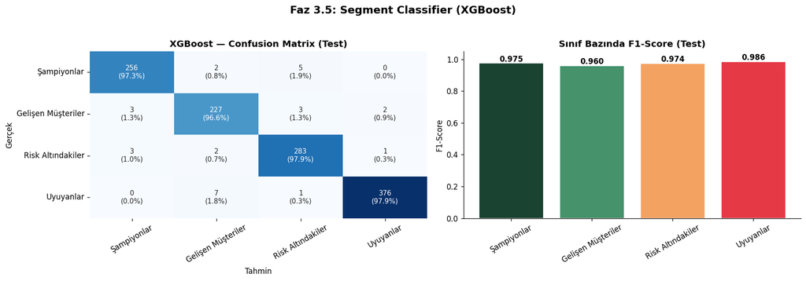

```
DETAYLI SINIFLANDIRMA RAPORU — XGBoost (Test Seti)
=================================================================
                    precision    recall  f1-score   support

       Şampiyonlar     0.9771    0.9734    0.9752       263
Gelişen Müşteriler     0.9538    0.9660    0.9598       235
 Risk Altındakiler     0.9692    0.9792    0.9742       289
         Uyuyanlar     0.9921    0.9792    0.9856       384

          accuracy                         0.9752      1171
         macro avg     0.9730    0.9744    0.9737      1171
      weighted avg     0.9754    0.9752    0.9753      1171

=================================================================

NOT: Hedef değişken K-Means çıktısıdır (ground truth değil).
     Model K-Means karar sınırlarını öğrenmektedir.
     Train=1.00 beklenen bir sonuçtur — deterministik etiket seti.
     Kritik metrik: Test weighted F1 = 0.9753
```

```python
# ═══════════════════════════════════════════════════════════════════
# FAZ 3.5.3: ŞAMPIYON DEĞERLENDİRME — Confusion Matrix & Rapor
# ═══════════════════════════════════════════════════════════════════

fig, axes = plt.subplots(1, 2, figsize=(15, 5))

# ── Confusion Matrix ──────────────────────────────────────────────
cm_seg = confusion_matrix(y_seg_test, y_seg_pred)
cm_pct = cm_seg.astype(float) / cm_seg.sum(axis=1, keepdims=True) * 100

annot = np.array([[f"{cm_seg[i,j]}\n({cm_pct[i,j]:.1f}%)"
                   for j in range(4)] for i in range(4)])

sns.heatmap(cm_seg, annot=annot, fmt='', cmap='Blues', cbar=False,
            ax=axes[0],
            xticklabels=SEGMENT_ORDER, yticklabels=SEGMENT_ORDER,
            annot_kws={"size": 9})
axes[0].set_title(f'{best_seg_name} — Confusion Matrix (Test)', fontweight='bold')
axes[0].set_xlabel('Tahmin'); axes[0].set_ylabel('Gerçek')
axes[0].tick_params(axis='x', rotation=30)
axes[0].tick_params(axis='y', rotation=0)

# ── Per-Class F1 Bar Chart ────────────────────────────────────────
report = classification_report(y_seg_test, y_seg_pred,
                                target_names=SEGMENT_ORDER,
                                output_dict=True)
per_class_f1 = [report[s]['f1-score'] for s in SEGMENT_ORDER]
colors = [SEGMENT_COLORS[s] for s in SEGMENT_ORDER]

bars = axes[1].bar(SEGMENT_ORDER, per_class_f1, color=colors, edgecolor='white')
axes[1].set_ylim(0, 1.05)
axes[1].set_ylabel('F1-Score')
axes[1].set_title('Sınıf Bazında F1-Score (Test)', fontweight='bold')
axes[1].tick_params(axis='x', rotation=30)
for bar, v in zip(bars, per_class_f1):
    axes[1].text(bar.get_x() + bar.get_width()/2, v + 0.01,
                 f'{v:.3f}', ha='center', fontsize=10, fontweight='bold')

plt.suptitle(f'Faz 3.5: Segment Classifier ({best_seg_name})',
             fontsize=14, fontweight='bold', y=1.03)
plt.tight_layout()
plt.show()

# ── Metin Raporu ─────────────────────────────────────────────────
print(f"\nDETAYLI SINIFLANDIRMA RAPORU — {best_seg_name} (Test Seti)")
print("=" * 65)
print(classification_report(y_seg_test, y_seg_pred,
                             target_names=SEGMENT_ORDER, digits=4))
print("=" * 65)
print("\nNOT: Hedef değişken K-Means çıktısıdır (ground truth değil).")
print("     Model K-Means karar sınırlarını öğrenmektedir.")
print(f"     Train=1.00 beklenen bir sonuçtur — deterministik etiket seti.")
print(f"     Kritik metrik: Test weighted F1 = {seg_results[best_seg_name]['Test F1 (w)']:.4f}")
```

### FAZ 3.5.4: SHAP — Model Yorumlanabilirliği (XAI)

#### İş Gerekçesi

Çoklu sınıflandırma modellerinde global özellik önemi (feature importance), hangi özelliğin hangi spesifik sınıfı tetiklediğini açıklamakta yetersiz kalır. Örneğin, bir özelliğin genel önemi yüksek olabilir ancak bu özellik sadece "Şampiyonlar" segmentini bulmaya mı yarıyor, yoksa "Uyuyanlar"ı mı ayırt ediyor? Bu soruya cevap vermek, modelin K-Means algoritmasının mantığını ne kadar doğru taklit ettiğini doğrulamak ve gerçek zamanlı CRM aksiyonlarını beslemek adına kritik bir zorunluluktur.

#### Teknik Detay ve Karar Gerekçeleri

- **Multiclass SHAP Dekompozisyonu:** `shap.TreeExplainer` çıktısı çoklu sınıflarda her bir kategori için ayrı bir SHAP matrisi üretir. Hücrede, 4 farklı segment için beeswarm dağılımları bağımsız olarak görselleştirilmiş ve her bir özelliğin ilgili segment karar sınırına olan local etki yönü mühürlenmiştir.
- **Ortalama Mutlak SHAP Önceliklendirmesi:** Her özellik ve her sınıf için ortalama mutlak SHAP değerleri (`mean_abs_shap`) hesaplanarak, hangi değişkenin hangi müşteri kümesini ayırt etmede ne kadar matematiksel ağırlığa sahip olduğu matris formatında raporlanmıştır.

```
SHAP analizi çalışıyor...
```

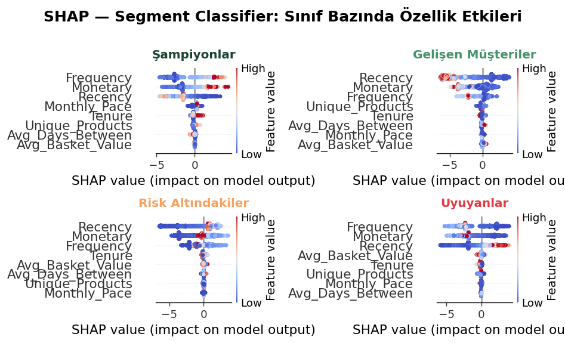

```
GLOBAL SHAP ÖNEMİ (ortalama |SHAP| — sınıf bazında)
======================================================================
                  Şampiyonlar  Gelişen Müşteriler  Risk Altındakiler  Uyuyanlar
Frequency              2.5802              0.8627             1.2780     2.2977
Monetary               1.6477              1.4586             1.7840     1.8198
Recency                1.3715              3.4540             2.3161     1.7656
Monthly_Pace           0.3247              0.0915             0.0421     0.0347
Tenure                 0.2527              0.1276             0.1101     0.1050
Unique_Products        0.1514              0.1462             0.0459     0.0927
Avg_Days_Between       0.0697              0.1017             0.0528     0.0171
Avg_Basket_Value       0.0246              0.0762             0.0677     0.1410
======================================================================

FAZ 3.5 TAMAMLANDI.
  Şampiyon : XGBoost  |  Test weighted F1 : 0.9753
  Kullanım : Yeni müşteri için K-Means çalıştırmadan hızlı segment tahmini.
  Kısıt    : Etiketler K-Means çıktısı — ground truth değil.
```

```python
# ═══════════════════════════════════════════════════════════════════
# FAZ 3.5.4: SHAP — Segment Classifier Yorumlanabilirliği
# ═══════════════════════════════════════════════════════════════════
# Multiclass SHAP: her sınıf için ayrı SHAP matris döner.
# TreeExplainer → shap_values shape: (n_samples, n_features, n_classes)
# veya liste [class_0, class_1, class_2, class_3].
# Her sınıfın beeswarm'ını yan yana gösteriyoruz.

print("SHAP analizi çalışıyor...")

seg_explainer   = shap.TreeExplainer(best_seg_model)
seg_shap_values = seg_explainer.shap_values(X_seg_test)

# XGBoost multiclass: liste [n_classes] veya 3D array
if isinstance(seg_shap_values, list):
    shap_per_class = seg_shap_values                        # liste
else:
    shap_per_class = [seg_shap_values[:, :, i]
                      for i in range(seg_shap_values.shape[2])]  # 3D → liste

fig, axes = plt.subplots(2, 2, figsize=(18, 14))
axes = axes.flatten()

for i, seg_name in enumerate(SEGMENT_ORDER):
    plt.sca(axes[i])
    shap.summary_plot(
        shap_per_class[i], X_seg_test,
        plot_type="dot", cmap="coolwarm",
        show=False, max_display=8
    )
    axes[i].set_title(f'{seg_name}', fontweight='bold', fontsize=12,
                      color=SEGMENT_COLORS[seg_name], pad=10)

plt.suptitle('SHAP — Segment Classifier: Sınıf Bazında Özellik Etkileri',
             fontsize=15, fontweight='bold', y=1.01)
plt.tight_layout()
plt.show()

# ── Global Önem: hangi özellik hangi segmenti en çok ayırt ediyor? ─
mean_abs_shap = pd.DataFrame(
    {seg: np.abs(shap_per_class[i]).mean(axis=0)
     for i, seg in enumerate(SEGMENT_ORDER)},
    index=X_seg_test.columns
).sort_values('Şampiyonlar', ascending=False)

print("\nGLOBAL SHAP ÖNEMİ (ortalama |SHAP| — sınıf bazında)")
print("=" * 70)
print(mean_abs_shap.round(4).to_string())
print("=" * 70)
print("\nFAZ 3.5 TAMAMLANDI.")
print(f"  Şampiyon : XGBoost  |  Test weighted F1 : {seg_results[best_seg_name]['Test F1 (w)']:.4f}")
print(f"  Kullanım : Yeni müşteri için K-Means çalıştırmadan hızlı segment tahmini.")
print(f"  Kısıt    : Etiketler K-Means çıktısı — ground truth değil.")
```